# Renshaw Figures

#eDNA data script

#clean global environment

```r
rm(list=ls())
```

load libraries

```r
#plot package
library(ggplot2)

#combing plots package
library(gridExtra)
```

set working directory

```r
setwd("Data_directory")
```

Inport data usinc read.csv

```r
Ren1<-read.csv("RenshawPreservationRdata.csv")
```

Check the data

```r
#general look
head(Ren1)

#variable types
str(Ren1)
```

Right so figure 1 from Renshaw et al. is broken into a series of plots

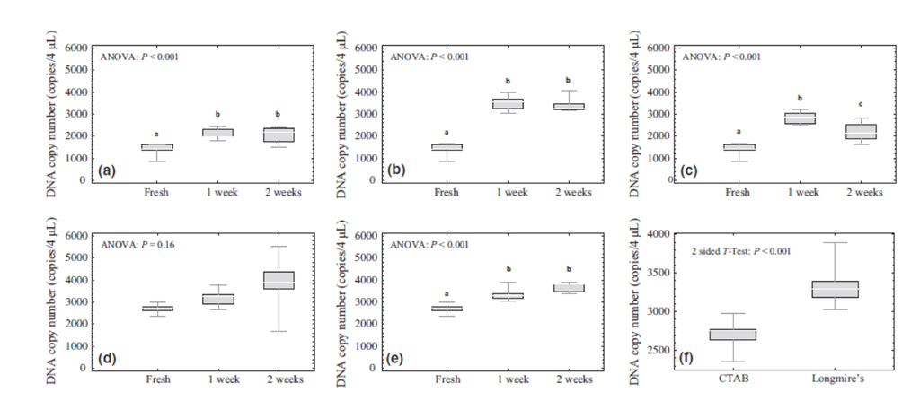

Ren1

Panel a) is time versus DNA copy number, but only for Temperature == -20 and Preservation == CTAB

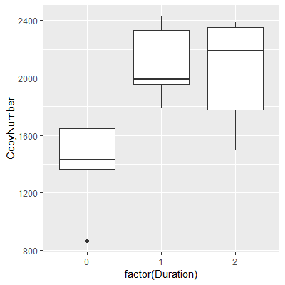

```r
ggplot(data=Ren1[Ren1$PreservationBuffer=="CTAB"&Ren1$Temperature==-20,],aes(x=factor(Duration),y=CopyNumber))+
  geom_boxplot()
```

We can see how they calculated the stats using the standard anova function in R

```r
anova(lm(data=Ren1[Ren1$PreservationBuffer=="CTAB"&Ren1$Temperature==-20,],CopyNumber~factor(Duration)))
```

[output not shown]

Fix the x and y axis and add some text to the plot

[figure not shown]

```r
ggplot(data=Ren1[Ren1$PreservationBuffer=="CTAB"&Ren1$Temperature==-20,],aes(x=factor(Duration),y=CopyNumber))+
  theme_bw()+
  stat_boxplot(geom='errorbar', linetype=1, width=0.5)+
  geom_boxplot()+
  xlab("")+
  ylab(bquote('DNA copy number (copies/4 ' ~mu~ 'L)'*''))+
  scale_x_discrete(labels=c("0" = "Fresh", "1" = "1 week","2" = "2 weeks"))+
  annotate("text", x = 1, y = 1800, label = "a")+
  annotate("text", x = 2, y = 2600, label = "b")+
  annotate("text", x = 3, y = 2600, label = "b")+
  annotate("text", x = 1, y = 5000, label = "ANOVA: p < 0.01")
```

Panel b) is similar (just change the x groupings) here Temperature == 20 and Preservation == CTAB

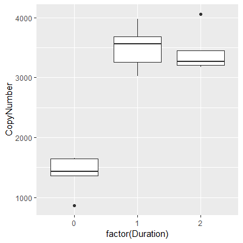

```r
ggplot(data=Ren1[Ren1$PreservationBuffer=="CTAB"&Ren1$Temperature==20,],aes(x=factor(Duration),y=CopyNumber))+
  geom_boxplot()
```

Fix the x and y axis and add some text to the plot

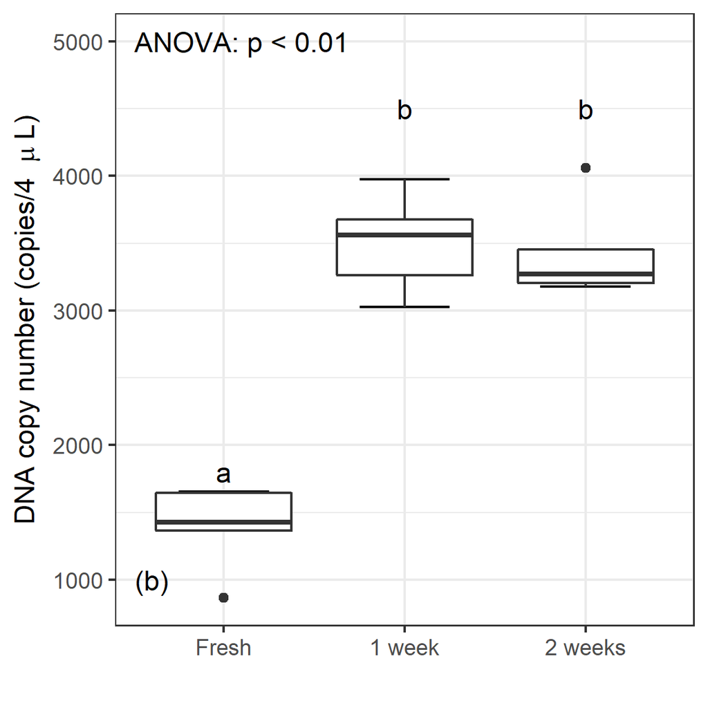

```r
ggplot(data=Ren1[Ren1$PreservationBuffer=="CTAB"&Ren1$Temperature==20,],aes(x=factor(Duration),y=CopyNumber))+
  theme_bw()+
  stat_boxplot(geom='errorbar', linetype=1, width=0.5)+
  geom_boxplot()+
  xlab("")+
  ylab(bquote('DNA copy number (copies/4 ' ~mu~ 'L)'*''))+
  scale_x_discrete(labels=c("0" = "Fresh", "1" = "1 week","2" = "2 weeks"))+
  annotate("text", x = 1, y = 1800, label = "a")+
  annotate("text", x = 2, y = 4500, label = "b")+
  annotate("text", x = 3, y = 4500, label = "b")+
  annotate("text", x = 1.1, y = 5000, label = "ANOVA: p < 0.01")+
  annotate("text", x = 0.6, y = 1000, label = "(b)")
```

Statistics as performed in Renshaw *et al.* are fairly simple using ANOVA (a specific type of linear regression where the explanatory variables are factors)

```r
anova(lm(data=Ren1[Ren1$PreservationBuffer=="CTAB"&Ren1$Temperature==20,],CopyNumber~factor(Duration)))
```

[output not shown]

You can combine multiple ggplot figures into a single plot using grid extra

First create an object for each figure

```r
p1<-ggplot(data=Ren1[Ren1$PreservationBuffer=="CTAB"&Ren1$Temperature==-20,],aes(x=factor(Duration),y=CopyNumber))+
  theme_bw()+
  stat_boxplot(geom='errorbar', linetype=1, width=0.5)+
  geom_boxplot()+
  xlab("")+
  ylab(bquote('DNA copy number (copies/4 ' ~mu~ 'L)'*''))+
  scale_x_discrete(labels=c("0" = "Fresh", "1" = "1 week","2" = "2 weeks"))+
  annotate("text", x = 1, y = 1800, label = "a")+
  annotate("text", x = 2, y = 2600, label = "b")+
  annotate("text", x = 3, y = 2600, label = "b")+
  annotate("text", x = 1.3, y = 5000, label = "ANOVA: p < 0.01")+
  annotate("text", x = 0.6, y = 1000, label = "(a)")

p2<-ggplot(data=Ren1[Ren1$PreservationBuffer=="CTAB"&Ren1$Temperature==20,],aes(x=factor(Duration),y=CopyNumber))+
  theme_bw()+
  stat_boxplot(geom='errorbar', linetype=1, width=0.5)+
  geom_boxplot()+
  xlab("")+
  ylab(bquote('DNA copy number (copies/4 ' ~mu~ 'L)'*''))+
  scale_x_discrete(labels=c("0" = "Fresh", "1" = "1 week","2" = "2 weeks"))+
  annotate("text", x = 1, y = 1800, label = "a")+
  annotate("text", x = 2, y = 4500, label = "b")+
  annotate("text", x = 3, y = 4500, label = "b")+
  annotate("text", x = 1.3, y = 5000, label = "ANOVA: p < 0.01")+
  annotate("text", x = 0.6, y = 1000, label = "(b)")
```

Then combine them using grid

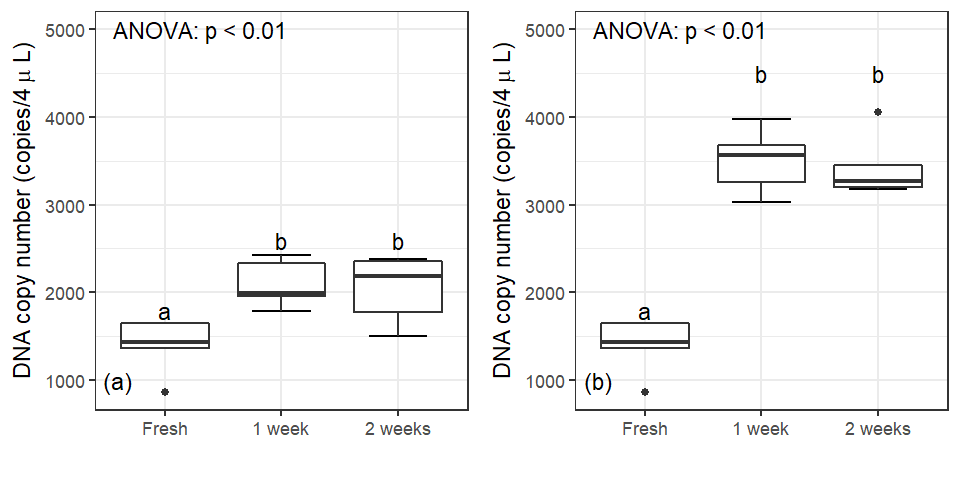

```r
grid.arrange(p1,p2,nrow=1)

#save using png(), pdf() ect

png(filename="FileName.png",width=960,height=480,res=150)
grid.arrange(p1,p2,nrow=1)
dev.off()
```

Now try Using the existing data set create the other panel graphs

Using the other Renshaw data sets create figures 2 , 3, and 4